# HW 01

Author

Sravani Maddineni

## 0 - Setup

```r
if (!require("pacman"))
  install.packages("pacman")

# use this line for installing/loading
pacman::p_load(tidyverse,
               palmerpenguins)

devtools::install_github("tidyverse/dsbox")
```

## 1 - Road traffic accidents in Edinburgh

```r
# Load and glimpse the dataset
library(tidyverse)
library(hms)

accidents <- read_csv("data/accidents.csv")

# View structure: number of rows, columns, and variable types
glimpse(accidents)
```

```
Rows: 768
Columns: 31
$ id                 <chr> "2018950000002", "2018950000006", "2018950000012", …
$ easting            <dbl> 327174, 324874, 330500, 321890, 320120, 331752, 325…
$ northing           <dbl> 670941, 672457, 671750, 671640, 669330, 667988, 674…
$ longitude          <dbl> -3.167032, -3.204252, -3.114026, -3.251772, -3.2794…
$ latitude           <dbl> 55.92600, 55.93926, 55.93376, 55.93145, 55.91041, 5…
$ police_force       <dbl> 95, 95, 95, 95, 95, 95, 95, 95, 95, 95, 95, 95, 95,…
$ severity           <chr> "Slight", "Slight", "Slight", "Slight", "Slight", "…
$ vehicles           <dbl> 1, 1, 2, 3, 2, 3, 1, 1, 1, 2, 2, 1, 1, 1, 2, 1, 2, …
$ casualties         <dbl> 1, 1, 2, 1, 1, 1, 2, 1, 1, 1, 1, 1, 1, 4, 1, 1, 1, …
$ date               <chr> "31/12/2018", "30/12/2018", "03/01/2018", "01/01/20…
$ day_of_week        <chr> "Monday", "Sunday", "Wednesday", "Monday", "Thursda…
$ time               <time> 14:59:00, 12:50:00, 14:34:00, 02:25:00, 09:00:00, …
$ district           <dbl> 923, 923, 923, 923, 923, 923, 923, 923, 923, 923, 9…
```

[output cut: 18 more lines]

```r
# Preprocessing: convert date/time and classify as weekend/weekday
accidents <- accidents %>%
  mutate(
    date = as.Date(date),
    time = as_hms(time),
    day_type = if_else(weekdays(date) %in% c("Saturday", "Sunday"), "Weekend", "Weekday"),
    severity = factor(severity, levels = c("Fatal", "Serious", "Slight"))
  )
```

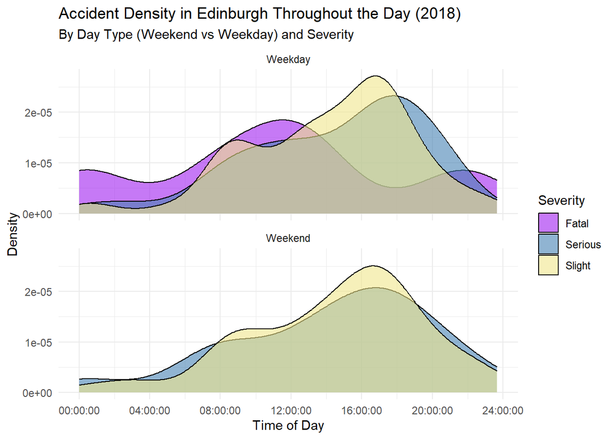

```r
# Density plot showing accident times by day type and severity
ggplot(accidents, aes(x = time, fill = severity)) +
  geom_density(alpha = 0.6) +
  facet_wrap(~day_type, ncol = 1) +
  scale_fill_manual(values = c("Fatal" = "purple", "Serious" = "steelblue", "Slight" = "khaki")) +
  labs(
    title = "Accident Density in Edinburgh Throughout the Day (2018)",
    subtitle = "By Day Type (Weekend vs Weekday) and Severity",
    x = "Time of Day",
    y = "Density",
    fill = "Severity"
  ) +
  theme_minimal()
```

Interpretation

The dataset contains records of traffic accidents in Edinburgh during 2018. After inspecting the structure with glimpse( ), we see variables such as date, time, location, and severity.

## 2 - NYC marathon winner

```r
# Load necessary libraries
# install.packages("openintro")
library(ggplot2)
library(openintro)
# Load the dataset
data("nyc_marathon")
head(nyc_marathon)
```

```
# A tibble: 6 × 7
   year name           country       time     time_hrs division note
  <dbl> <chr>          <chr>         <time>      <dbl> <chr>    <chr>
1  1970 Gary Muhrcke   United States 02:31:38     2.53 Men      Course record
2  1970 <NA>           <NA>                NA    NA    Women    No woman finish…
3  1971 Norman Higgins United States 02:22:54     2.38 Men      Course record
4  1971 Beth Bonner    United States 02:55:22     2.92 Women    World record
5  1972 Sheldon Karlin United States 02:27:52     2.46 Men      <NA>
6  1972 Nina Kuscsik   United States 03:08:41     3.14 Women    <NA>
```

```r
summary(nyc_marathon)
```

```
      year          name             country               time
 Min.   :1970   Length:108         Length:108         Min.   :02:04:58.000000
 1st Qu.:1983   Class :character   Class :character   1st Qu.:02:09:41.000000
 Median :1996   Mode  :character   Mode  :character   Median :02:22:54.000000
 Mean   :1996                                         Mean   :02:20:43.533333
 3rd Qu.:2010                                         3rd Qu.:02:27:14.000000
 Max.   :2023                                         Max.   :03:08:41.000000
                                                      NA's   :3
    time_hrs       division             note
 Min.   :2.083   Length:108         Length:108
 1st Qu.:2.161   Class :character   Class :character
 Median :2.382   Mode  :character   Mode  :character
 Mean   :2.345
 3rd Qu.:2.454
 Max.   :3.145
 NA's   :3
```

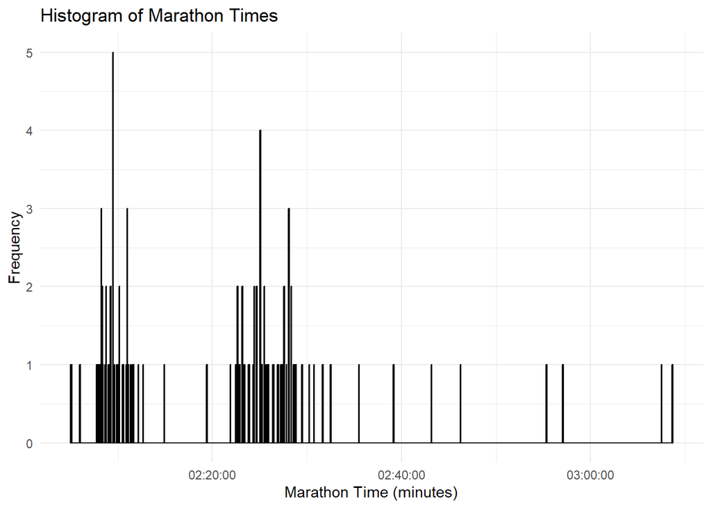

```r
# Histogram of marathon times
ggplot(data = nyc_marathon, aes(x = time)) +
  geom_histogram(binwidth = 5, fill = "lightblue", color = "black") +
  labs(
    title = "Histogram of Marathon Times",
    x = "Marathon Time (minutes)",
    y = "Frequency"
  ) +
  theme_minimal()
```

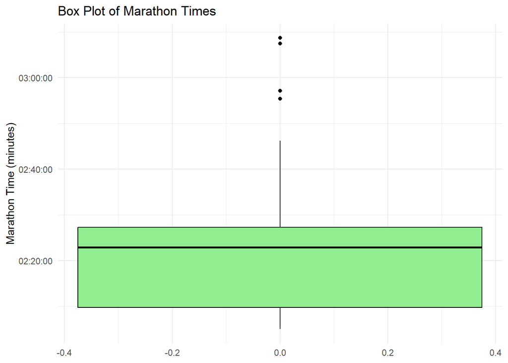

```r
# Box plot of marathon times
ggplot(nyc_marathon, aes(y=time)) +
geom_boxplot(fill="lightgreen", color="black") +
labs(title="Box Plot of Marathon Times", y="Marathon Time (minutes)") +
  theme_minimal()
```

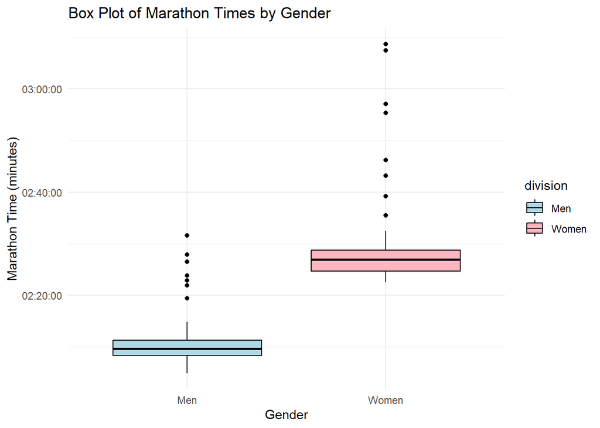

```r
# Create Side-by-Side Box Plots for Men and Women
ggplot(nyc_marathon, aes(x=division, y=time, fill=division)) +
geom_boxplot(color="black") +
scale_fill_manual(values=c("lightblue", "lightpink")) +
labs(title="Box Plot of Marathon Times by Gender", x="Gender", y="Marathon Time (minutes)")+
  theme_minimal()
```

```r
head(nyc_marathon)
```

```
# A tibble: 6 × 7
   year name           country       time     time_hrs division note
  <dbl> <chr>          <chr>         <time>      <dbl> <chr>    <chr>
1  1970 Gary Muhrcke   United States 02:31:38     2.53 Men      Course record
2  1970 <NA>           <NA>                NA    NA    Women    No woman finish…
3  1971 Norman Higgins United States 02:22:54     2.38 Men      Course record
4  1971 Beth Bonner    United States 02:55:22     2.92 Women    World record
5  1972 Sheldon Karlin United States 02:27:52     2.46 Men      <NA>
6  1972 Nina Kuscsik   United States 03:08:41     3.14 Women    <NA>
```

```r
summary(nyc_marathon)
```

```
      year          name             country               time
 Min.   :1970   Length:108         Length:108         Min.   :02:04:58.000000
 1st Qu.:1983   Class :character   Class :character   1st Qu.:02:09:41.000000
 Median :1996   Mode  :character   Mode  :character   Median :02:22:54.000000
 Mean   :1996                                         Mean   :02:20:43.533333
 3rd Qu.:2010                                         3rd Qu.:02:27:14.000000
 Max.   :2023                                         Max.   :03:08:41.000000
                                                      NA's   :3
    time_hrs       division             note
 Min.   :2.083   Length:108         Length:108
 1st Qu.:2.161   Class :character   Class :character
 Median :2.382   Mode  :character   Mode  :character
 Mean   :2.345
 3rd Qu.:2.454
 Max.   :3.145
 NA's   :3
```

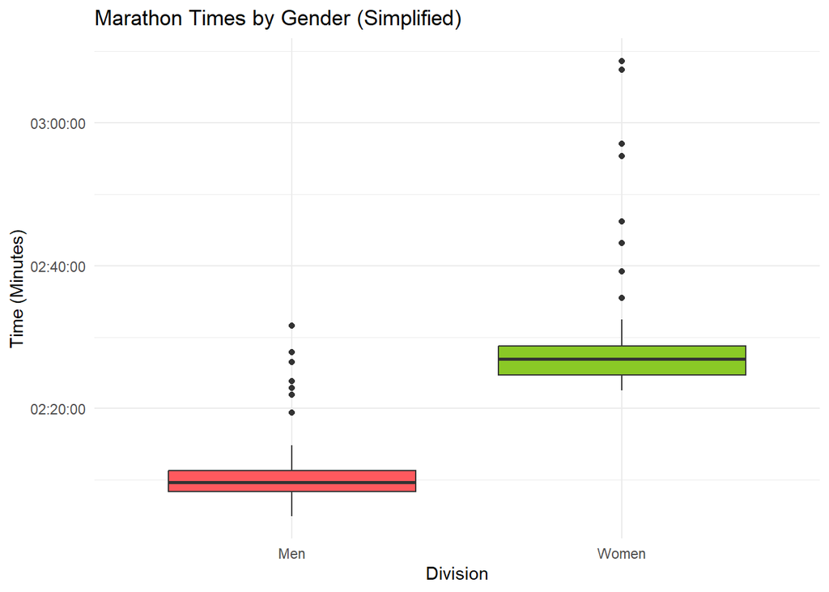

```r
# Identify and Remove Redundant Information::
ggplot(nyc_marathon, aes(x = division, y = time, fill = division)) +
  geom_boxplot(show.legend = FALSE) +
  scale_fill_manual(values = c("Men" = "#ff595e", "Women" = "#8ac926")) +
  labs(title = "Marathon Times by Gender (Simplified)",
       x = "Division",
       y = "Time (Minutes)") +
  theme_minimal()
```

```r
# Visualize Marathon Times Over the Years::
head(nyc_marathon)
```

```
# A tibble: 6 × 7
   year name           country       time     time_hrs division note
  <dbl> <chr>          <chr>         <time>      <dbl> <chr>    <chr>
1  1970 Gary Muhrcke   United States 02:31:38     2.53 Men      Course record
2  1970 <NA>           <NA>                NA    NA    Women    No woman finish…
3  1971 Norman Higgins United States 02:22:54     2.38 Men      Course record
4  1971 Beth Bonner    United States 02:55:22     2.92 Women    World record
5  1972 Sheldon Karlin United States 02:27:52     2.46 Men      <NA>
6  1972 Nina Kuscsik   United States 03:08:41     3.14 Women    <NA>
```

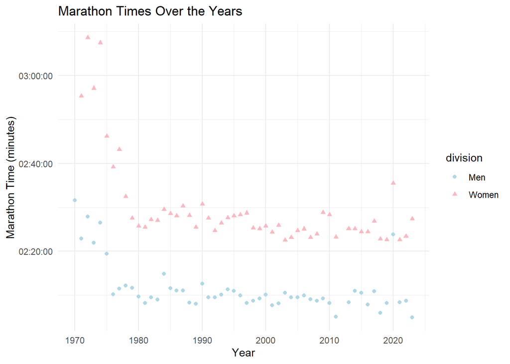

```r
ggplot(nyc_marathon, aes(x=year, y=time, color=division, shape=division)) +
geom_point() +
scale_color_manual(values=c("lightblue", "lightpink")) +
scale_shape_manual(values=c(16, 17)) +
labs(title="Marathon Times Over the Years", x="Year", y="Marathon Time (minutes)") +
theme_minimal()
```

Interpretation: Histogram: Shows the distribution of marathon times, illustrating the shape and spread of the data. Peaks, gaps, and overall density are visible. Box Plot: Provides a summary of the data’s central tendency and spread, highlighting median, quartiles, and outliers.

It does not show the overall distribution shape or frequency details. This plot compares marathon times between men and women. Different colors (light blue for men and light pink for women) visually distinguish between the two groups. You can see differences in median times, variability, and potential outliers for each gender.

This plot compares marathon times between men and women. Different colors (light blue for men and light pink for women) visually distinguish between the two groups. You can see differences in median times, variability, and potential outliers for each gender.

Time Series Plot: This plot shows how marathon times for men and women have changed over the years. Different colors and shapes represent men and women, allowing for a clear comparison of trends and changes in marathon performance over time. This visualization provides insights into how race times have evolved, which is not visible in the histogram or box plot.

## 3 - US counties

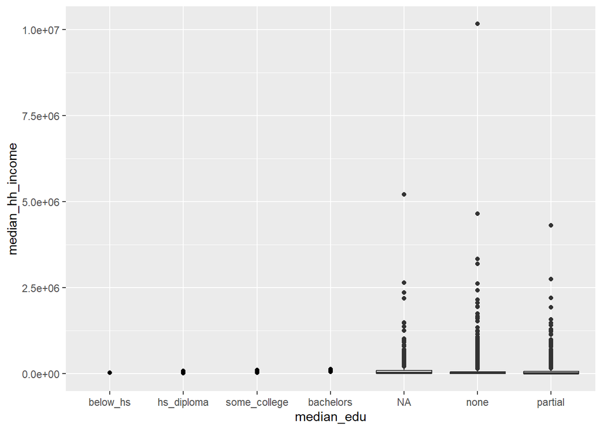

```r
library(tidyverse)
library(openintro)

data(county)
ggplot(county) + geom_point(aes(x = median_edu, y = median_hh_income)) +
  geom_boxplot(aes(x = smoking_ban, y = pop2017))
```

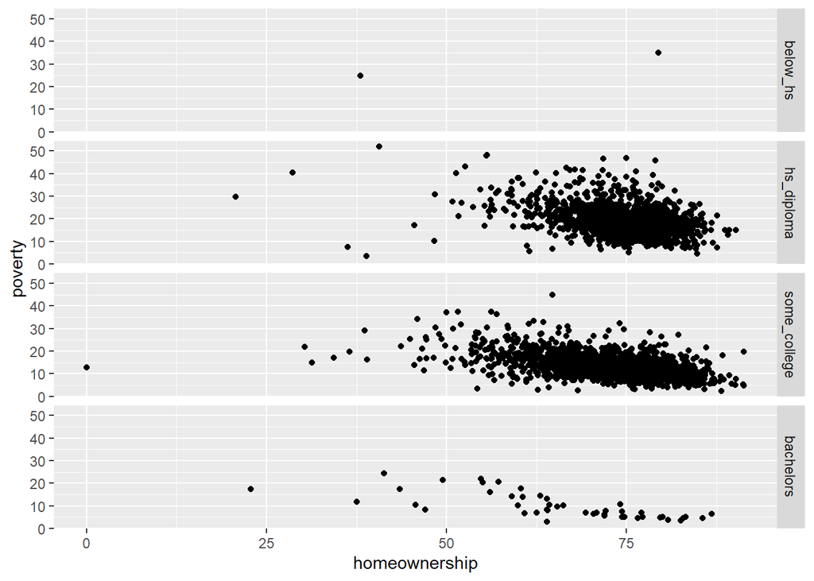

```r
  ggplot(county %>% filter(!is.na(median_edu))) + geom_point(aes(x=     homeownership, y = poverty)) + facet_grid(median_edu ~ .)
```

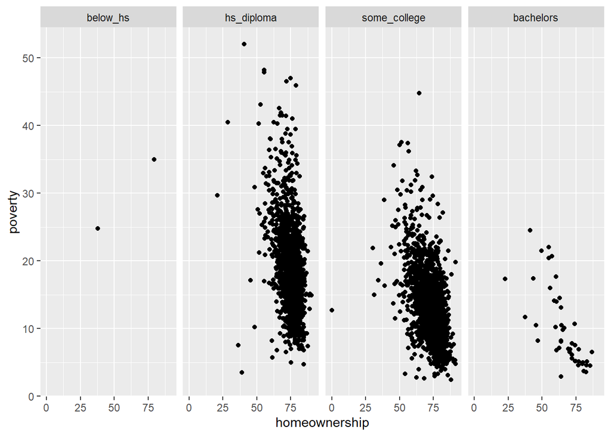

```r
  ggplot(county %>% filter(!is.na(median_edu))) + geom_point(aes(x = homeownership, y = poverty)) + facet_grid(. ~ median_edu)
```

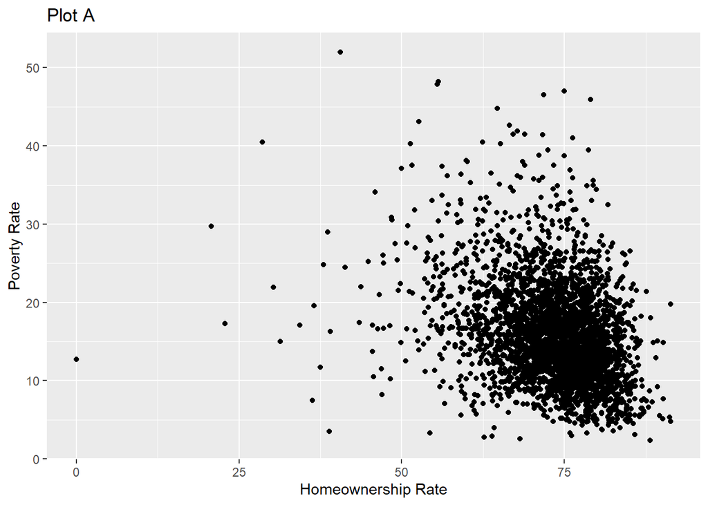

```r
# A Plot::
ggplot(county %>% filter(!is.na(median_edu))) +
  geom_point(aes(x = homeownership, y = poverty)) +
  ggtitle("Plot A") +
  xlab("Homeownership Rate") +
  ylab("Poverty Rate")
```

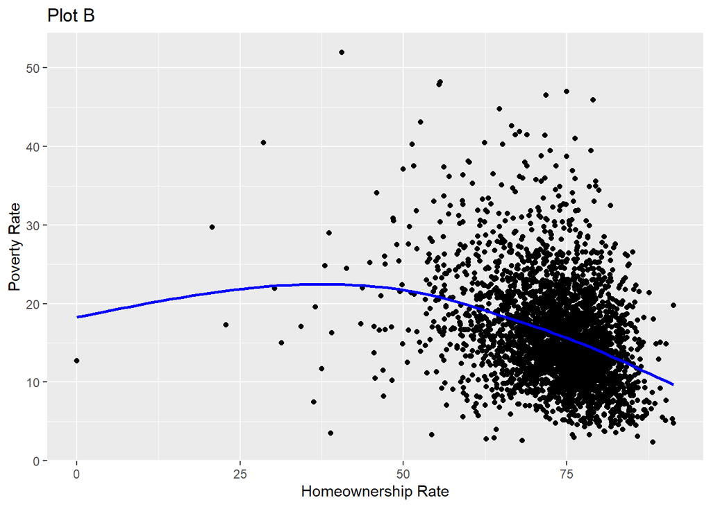

```r
# B Plot::
ggplot(county %>% filter(!is.na(median_edu))) +
  geom_point(aes(x = homeownership, y = poverty)) +
geom_smooth(aes(x = homeownership, y = poverty), se = FALSE, color = "blue") +
   ggtitle("Plot B") +
   xlab("Homeownership Rate") +
   ylab("Poverty Rate")
```

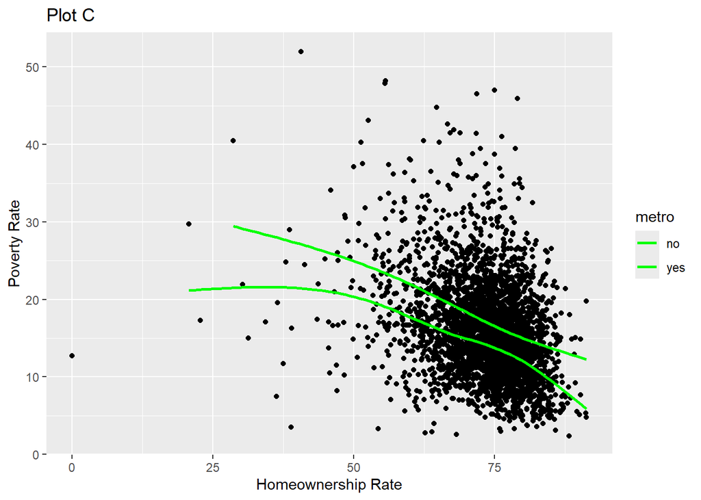

```r
# C Plot::
ggplot(county %>% filter(!is.na(median_edu))) +
   geom_point(aes(x = homeownership, y = poverty)) +
   geom_smooth(aes(x = homeownership, y = poverty, color = metro), se = FALSE   )+
   scale_color_manual(values = c("yes" = "green", "no" = "green")) +
    ggtitle("Plot C") +
    xlab("Homeownership Rate") +
    ylab("Poverty Rate")
```

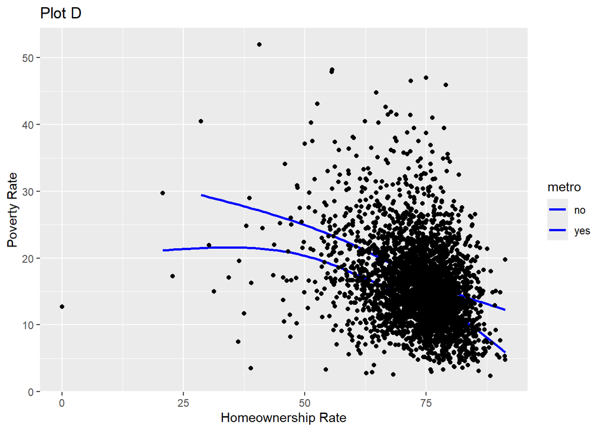

```r
# D Plot::
ggplot(county %>% filter(!is.na(median_edu))) +
  geom_smooth(aes(x = homeownership, y = poverty, color = metro), se = FALSE) +
  geom_point(aes(x = homeownership, y = poverty)) +
  scale_color_manual(values = c("yes" = "blue", "no" = "blue")) +
  ggtitle("Plot D") +
  xlab("Homeownership Rate") +
  ylab("Poverty Rate")
```

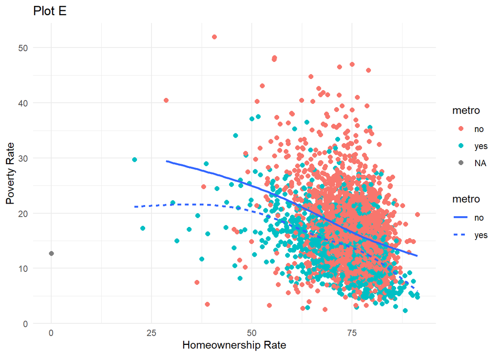

```r
#E Plot::
ggplot(county) +
  geom_point(aes(x = homeownership, y = poverty, color = metro), size = 2) +
  geom_smooth(aes(x = homeownership, y = poverty, linetype = metro), se = FALSE) +
  ggtitle("Plot E") +
  xlab("Homeownership Rate") +
  ylab("Poverty Rate") +
  theme_minimal()
```

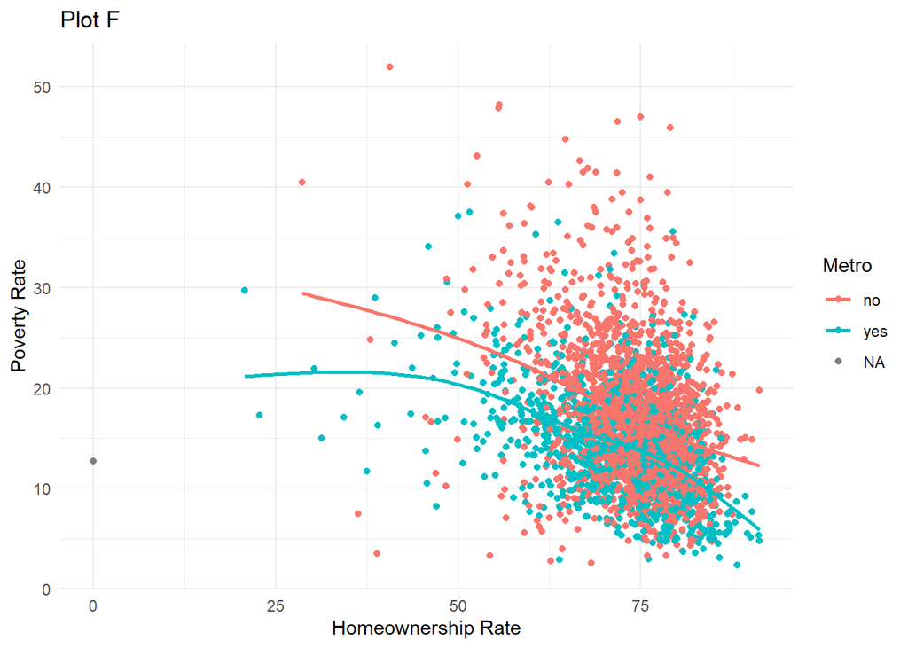

```r
# F Plot::
ggplot(county) +
  geom_point(aes(x = homeownership, y = poverty, color = metro)) +
  geom_smooth(aes(x = homeownership, y = poverty, color = metro), se = FALSE) +
  labs(color = "Metro") +
  ggtitle("Plot F") +
  xlab("Homeownership Rate") +
  ylab("Poverty Rate") +
  theme_minimal()
```

```r
summary(county)
```

```
     name                state         pop2000           pop2010
 Length:3142        Texas   : 254   Min.   :     67   Min.   :     82
 Class :character   Georgia : 159   1st Qu.:  11224   1st Qu.:  11114
 Mode  :character   Virginia: 133   Median :  24621   Median :  25872
                    Kentucky: 120   Mean   :  89650   Mean   :  98262
                    Missouri: 115   3rd Qu.:  61775   3rd Qu.:  66780
                    Kansas  : 105   Max.   :9519338   Max.   :9818605
                    (Other) :2256   NA's   :3
    pop2017           pop_change          poverty      homeownership
 Min.   :      88   Min.   :-33.6300   Min.   : 2.40   Min.   : 0.00
 1st Qu.:   10976   1st Qu.: -1.9700   1st Qu.:11.30   1st Qu.:69.50
 Median :   25857   Median : -0.0600   Median :15.20   Median :74.60
 Mean   :  103763   Mean   :  0.5339   Mean   :15.97   Mean   :73.27
 3rd Qu.:   67756   3rd Qu.:  2.3750   3rd Qu.:19.40   3rd Qu.:78.40
 Max.   :10163507   Max.   : 37.1900   Max.   :52.00   Max.   :91.30
 NA's   :3          NA's   :3          NA's   :2
   multi_unit    unemployment_rate  metro             median_edu
 Min.   : 0.00   Min.   : 1.620    no  :1974   below_hs    :   2
 1st Qu.: 6.10   1st Qu.: 3.520    yes :1165   hs_diploma  :1397
 Median : 9.70   Median : 4.360    NA's:   3   some_college:1695
 Mean   :12.32   Mean   : 4.611                bachelors   :  46
 3rd Qu.:15.90   3rd Qu.: 5.355                NA's        :   2
 Max.   :98.50   Max.   :19.070
                 NA's   :3
 per_capita_income median_hh_income   smoking_ban
 Min.   :10467     Min.   : 19264   none    :1927
 1st Qu.:21772     1st Qu.: 41126   partial : 635
 Median :25445     Median : 48073   complete:   0
 Mean   :26093     Mean   : 49765   NA's    : 580
 3rd Qu.:29276     3rd Qu.: 55771
 Max.   :69533     Max.   :129588
 NA's   :2         NA's   :2
```

```r
str(county)
```

```
tibble [3,142 × 15] (S3: tbl_df/tbl/data.frame)
 $ name             : chr [1:3142] "Autauga County" "Baldwin County" "Barbour County" "Bibb County" ...
 $ state            : Factor w/ 51 levels "Alabama","Alaska",..: 1 1 1 1 1 1 1 1 1 1 ...
 $ pop2000          : num [1:3142] 43671 140415 29038 20826 51024 ...
 $ pop2010          : num [1:3142] 54571 182265 27457 22915 57322 ...
 $ pop2017          : int [1:3142] 55504 212628 25270 22668 58013 10309 19825 114728 33713 25857 ...
 $ pop_change       : num [1:3142] 1.48 9.19 -6.22 0.73 0.68 -2.28 -2.69 -1.51 -1.2 -0.6 ...
 $ poverty          : num [1:3142] 13.7 11.8 27.2 15.2 15.6 28.5 24.4 18.6 18.8 16.1 ...
 $ homeownership    : num [1:3142] 77.5 76.7 68 82.9 82 76.9 69 70.7 71.4 77.5 ...
 $ multi_unit       : num [1:3142] 7.2 22.6 11.1 6.6 3.7 9.9 13.7 14.3 8.7 4.3 ...
 $ unemployment_rate: num [1:3142] 3.86 3.99 5.9 4.39 4.02 4.93 5.49 4.93 4.08 4.05 ...
 $ metro            : Factor w/ 2 levels "no","yes": 2 2 1 2 2 1 1 2 1 1 ...
 $ median_edu       : Factor w/ 4 levels "below_hs","hs_diploma",..: 3 3 2 2 2 2 2 3 2 2 ...
 $ per_capita_income: num [1:3142] 27842 27780 17892 20572 21367 ...
 $ median_hh_income : int [1:3142] 55317 52562 33368 43404 47412 29655 36326 43686 37342 40041 ...
 $ smoking_ban      : Factor w/ 3 levels "none","partial",..: 1 1 2 1 1 1 NA NA 1 1 ...
```

```r
head(county)
```

```
# A tibble: 6 × 15
  name           state  pop2000 pop2010 pop2017 pop_change poverty homeownership
  <chr>          <fct>    <dbl>   <dbl>   <int>      <dbl>   <dbl>         <dbl>
1 Autauga County Alaba…   43671   54571   55504       1.48    13.7          77.5
2 Baldwin County Alaba…  140415  182265  212628       9.19    11.8          76.7
3 Barbour County Alaba…   29038   27457   25270      -6.22    27.2          68
4 Bibb County    Alaba…   20826   22915   22668       0.73    15.2          82.9
5 Blount County  Alaba…   51024   57322   58013       0.68    15.6          82
6 Bullock County Alaba…   11714   10914   10309      -2.28    28.5          76.9
# ℹ 7 more variables: multi_unit <dbl>, unemployment_rate <dbl>, metro <fct>,
#   median_edu <fct>, per_capita_income <dbl>, median_hh_income <int>,
#   smoking_ban <fct>
```

```r
tail(county)
```

```
# A tibble: 6 × 15
  name            state pop2000 pop2010 pop2017 pop_change poverty homeownership
  <chr>           <fct>   <dbl>   <dbl>   <int>      <dbl>   <dbl>         <dbl>
1 Sublette County Wyom…    5920   10247    9799      -3.67     7.4          73.6
2 Sweetwater Cou… Wyom…   37613   43806   43534      -3.57    12            73.7
3 Teton County    Wyom…   18251   21294   23265       4.21     6.8          60.8
4 Uinta County    Wyom…   19742   21118   20495      -2.22    14.9          73.7
5 Washakie County Wyom…    8289    8533    8064      -4.31    12.8          70.9
6 Weston County   Wyom…    6644    7208    6927      -2.93    14.4          77.9
# ℹ 7 more variables: multi_unit <dbl>, unemployment_rate <dbl>, metro <fct>,
#   median_edu <fct>, per_capita_income <dbl>, median_hh_income <int>,
#   smoking_ban <fct>
```

```r
unique(county$metro)
```

```
[1] yes  no   <NA>
Levels: no yes
```

```r
sum(is.na(county$metro))
```

```
[1] 3
```

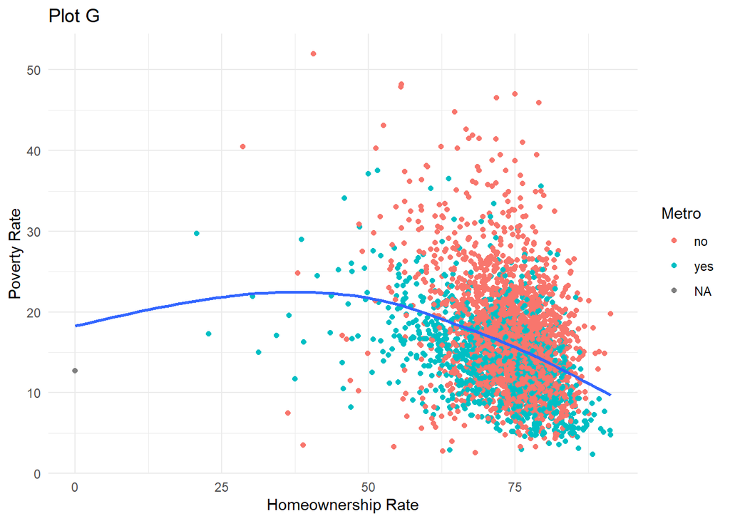

```r
# G Plot::
ggplot(county) +
  geom_point(aes(x = homeownership, y = poverty, color = metro)) +
  geom_smooth(aes(x = homeownership, y = poverty), se = FALSE) +
  labs(color = "Metro") +
  ggtitle("Plot G") +
  xlab("Homeownership Rate") +
  ylab("Poverty Rate") +
  theme_minimal()
```

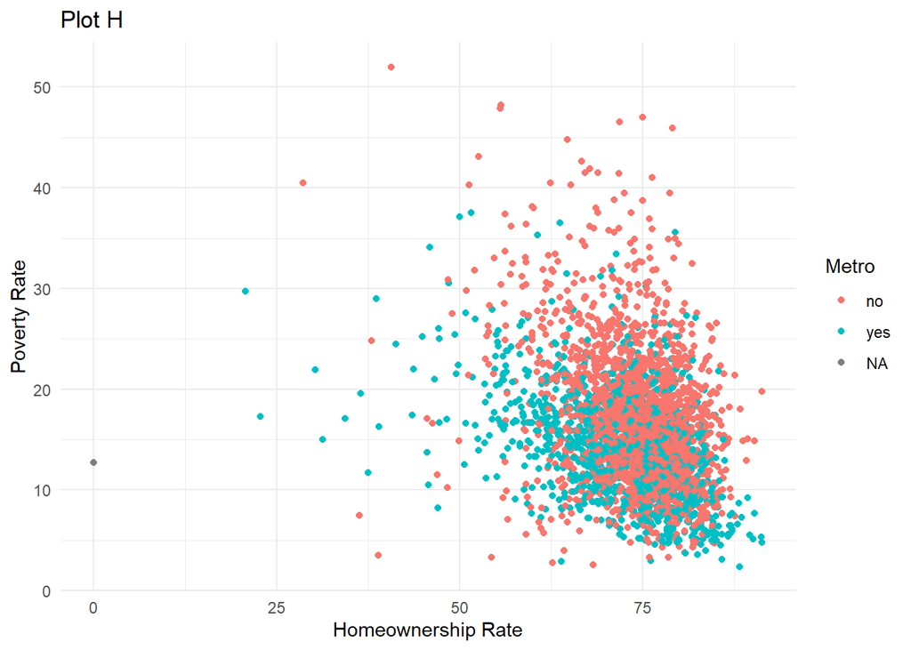

```r
# H Plot::
ggplot(county) +
  geom_point(aes(x = homeownership, y = poverty, color = metro)) +
  labs(color = "Metro") +
  ggtitle("Plot H") +
  xlab("Homeownership Rate") +
  ylab("Poverty Rate") +
  theme_minimal()
```

**Interpretation:**

For plot A:

This scatter plot shows a negative relationship higher homeownership tends to associate with lower poverty.

For plot B:

The smoothed line makes the negative trend more evident compared to the raw points.

For plot C:

Both metro categories are plotted with green lines this redundancy reduces clarity.

For plot D:

Swapping layers doesn’t fix the redundancy. All metro lines are blue, making grouping meaningless.

For plot E:

This plot uses both color and line type to differentiate metro status, improving clarity.

For plot F:

This is a clean and effective use of color and smoothers for metro vs non-metro comparisons.

For plot G:

This version shows only one trend line but colors points less cluttered but less detail about each group.

For plot H:

Simple and clear view of the raw data, no trend lines included.

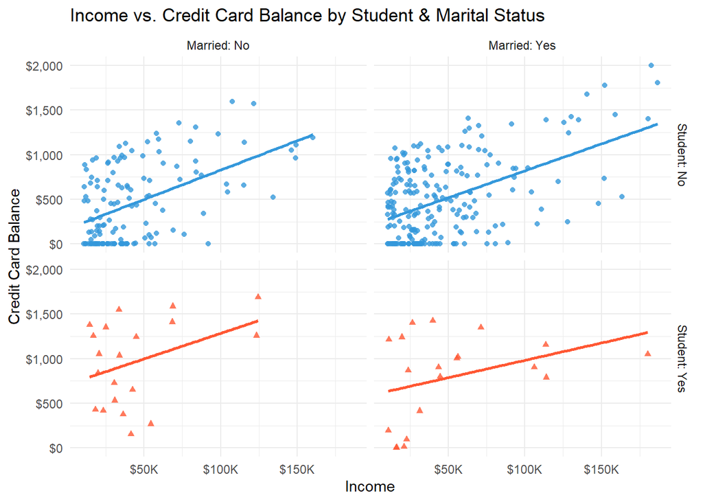

```r
library(tidyverse)
library(scales)

# Load the dataset
credit <- read_csv("data/credit.csv")

#| label: credit-balance-vs-income
ggplot(credit, aes(x = income, y = balance, color = student, shape = student)) +
  geom_point(alpha = 0.8, show.legend = FALSE) +
  geom_smooth(method = "lm", se = FALSE, show.legend = FALSE) +
  facet_grid(student ~ married, labeller = labeller(
    student = c("Yes" = "Student: Yes", "No" = "Student: No"),
    married = c("Yes" = "Married: Yes", "No" = "Married: No"))) +
  scale_color_manual(values = c("Yes" = "#ff5733", "No" = "#3498db")) +
  scale_x_continuous(labels = label_dollar(prefix = "$", suffix = "K")) +
  scale_y_continuous(labels = label_dollar(prefix = "$")) +
  labs(
    title = "Income vs. Credit Card Balance by Student & Marital Status",
    x = "Income",
    y = "Credit Card Balance") +
  theme_minimal()
```

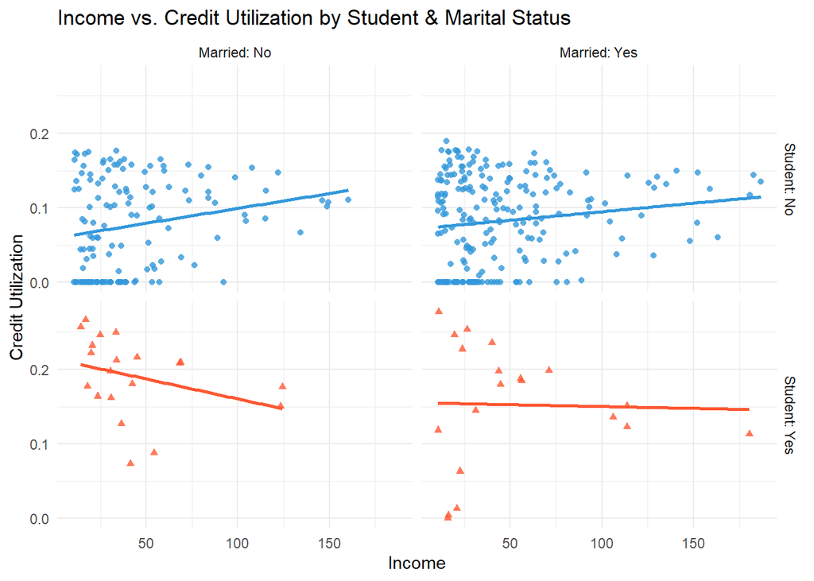

```r
#| label: credit-utilization
# Calculate utilization
credit <- credit %>%
  mutate(utilization = balance / limit)

# Plot utilization vs income
ggplot(credit, aes(x = income, y = utilization, color = student, shape = student)) +
  geom_point(alpha = 0.8, show.legend = FALSE) +
  geom_smooth(method = "lm", se = FALSE, show.legend = FALSE) +
  facet_grid(student ~ married, labeller = labeller(
    student = c("Yes" = "Student: Yes", "No" = "Student: No"),
    married = c("Yes" = "Married: Yes", "No" = "Married: No"))) +
  scale_color_manual(values = c("Yes" = "#ff5733", "No" = "#3498db")) +
  labs(
    title = "Income vs. Credit Utilization by Student & Marital Status",
    x = "Income", y = "Credit Utilization") +
  theme_minimal()
```

Interpretation:

In part (a), the plot shows how income is related to credit card balance, separated by whether someone is a student and whether they are married. We can see that people with higher incomes tend to have higher credit card balances. However, students especially those who are not married tend to carry higher balances even if they earn less. This suggests that being a student might lead to more credit usage.

In part (b), based on what we see in the plot, the variables “student” and “married” seem useful for predicting credit card balance. This is because the relationship between income and balance changes depending on whether someone is a student or married.

In part (c), we looked at credit utlization, which is how much of their credit limit someone is using (balance ÷ limit). The plot shows that students generally have higher utilization rates. Unlike balance, utilization doesn’t increase as clearly with income, which means people with more income don’t always use more of their credit.

In part (d), we can see that the relationship between income and credit utilization is not as strong as it is with credit balance. So, while income helps explain balance, it doesn’t explain utilization as well. This is important because utilization tells us more about how someone is managing their available credit, not just how much they owe.

## 5 - Napoleon’s march.

```r
library(ggplot2)
library(scales)
library(gridExtra)
library(dplyr)
library(ggrepel)
library(readr)

napoleon <- read_rds("./data/napoleon.rds")
Minard.troops <- napoleon$troops
Minard.cities <- napoleon$cities
Minard.temp <- napoleon$temp
summary(Minard.troops)
```

```
      long            lat          survivors       direction
 Min.   :24.00   Min.   :54.10   Min.   :  4000   Length:51
 1st Qu.:24.80   1st Qu.:54.40   1st Qu.: 20000   Class :character
 Median :28.30   Median :54.90   Median : 40000   Mode  :character
 Mean   :28.97   Mean   :54.93   Mean   : 91218
 3rd Qu.:32.00   3rd Qu.:55.30   3rd Qu.:113550
 Max.   :37.70   Max.   :55.80   Max.   :340000
     group
 Min.   :1.000
 1st Qu.:1.000
 Median :1.000
 Mean   :1.431
 3rd Qu.:2.000
 Max.   :3.000
```

```r
summary(Minard.cities)
```

```
      long            lat            city
 Min.   :24.00   Min.   :53.90   Length:20
 1st Qu.:27.68   1st Qu.:54.40   Class :character
 Median :30.30   Median :54.95   Mode  :character
 Mean   :30.79   Mean   :54.87
 3rd Qu.:34.33   3rd Qu.:55.30
 Max.   :37.60   Max.   :55.80
```

```r
summary(Minard.temp)
```

```
      long            temp           month                day
 Min.   :25.30   Min.   :-30.00   Length:9           Min.   : 1.00
 1st Qu.:27.20   1st Qu.:-24.00   Class :character   1st Qu.: 7.00
 Median :29.20   Median :-20.00   Mode  :character   Median :14.00
 Mean   :30.63   Mean   :-15.67                      Mean   :14.56
 3rd Qu.:33.20   3rd Qu.: -9.00                      3rd Qu.:24.00
 Max.   :37.60   Max.   :  0.00                      Max.   :28.00
      date
 Min.   :1812-10-18
 1st Qu.:1812-11-09
 Median :1812-11-24
 Mean   :1812-11-17
 3rd Qu.:1812-12-01
 Max.   :1812-12-07
```

[figure not shown]

```r
# Define breaks for the size scale
breaks <- c(1, 2, 3) * 10^5

plot_troops_detailed <- ggplot(Minard.troops, aes(x = long, y = lat)) +
  geom_path(aes(size = survivors, colour = direction, group = group),
            lineend = "round") +
  geom_point(data = Minard.cities, aes(x = long, y = lat),
             color = "red", size = 3, shape = 21, fill = "white") +
  geom_text_repel(data = Minard.cities, aes(x = long, y = lat, label = city),
                  size = 3, nudge_x = 0.5, nudge_y = 0.5) +
  scale_size(name = "Survivors", range = c(1, 10),
             breaks = breaks, labels = scales::comma(breaks)) +
  scale_color_manual(name = "Direction",
                     values = c("Advance" = "#E8CBAB", "Retreat" = "#1F1A1B")) +
  coord_cartesian(xlim = c(24, 38)) +
  labs(x = NULL, y = NULL) +
  guides(color = FALSE, size = FALSE) +
  theme_void()

# To display the plot
plot_troops_detailed
```

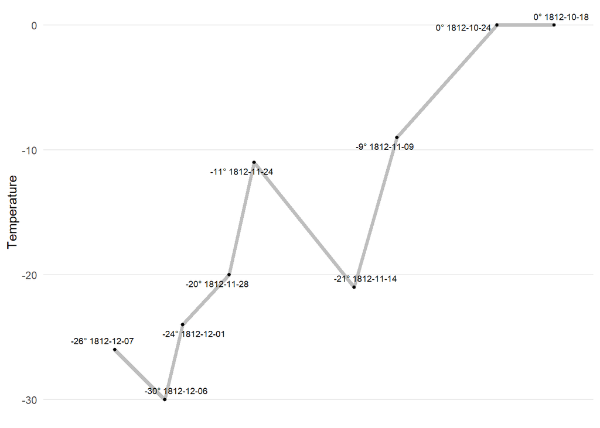

```r
# Prepare labels for the temperature plot
Minard.temp <- Minard.temp %>%
mutate(label = paste0(temp, "° ", date))
# Create the temperature plot
plot_temp <- ggplot(Minard.temp, aes(long, temp)) +
geom_path(color = "grey", size = 1.5) +
geom_point(size = 1) +
geom_text_repel(aes(label = label), size = 2.5) +
coord_cartesian(xlim = c(24, 38)) +
labs(x = NULL, y = "Temperature") +
theme_bw() +
theme(panel.grid.major.x = element_blank(),
panel.grid.minor.x = element_blank(),
panel.grid.minor.y = element_blank(),
axis.text.x = element_blank(),
axis.ticks = element_blank(),
panel.border = element_blank())
plot_temp
```

[figure not shown]

```r
grid.arrange(plot_troops_detailed, plot_temp, nrow = 2, heights = c(3.5, 1.2))
```

Description:

First section installs and loads the required R packages for data manipulation and plotting. It then reads the napoleon.rds file to load the datasets containing information on troops, cities, and temperatures. Reference: Friendly, M. (2018, January 22). Minard meets ggplot2. Retrieved February 16, 2025, from http://euclid.psych.yorku.ca/www/psy6135/tutorials/Minard.html.

The code generates a detailed plot of Napoleon’s troop movements. It uses geom_path to illustrate the route of the troops, with line thickness varying based on the number of survivors. geom_point is used to mark the locations of cities, while geom_text_repel adds city labels, avoiding overlap. scale_size and scale_color_manual customize the appearance of the plot by adjusting the size and color, respectively. coord_cartesian is applied to set the x-axis limits, and theme_void removes all additional elements like axis lines and labels for a clean presentation.

This code generates a plot depicting temperature changes along the route. It uses geom_path to trace the temperature variations, geom_point to display data points, and geom_text_repel to label the temperature data while preventing overlap. coord_cartesian sets the x-axis limits, and theme_bw provides a clean, minimal background. Additionally, theme is used to further customize the plot by removing grid lines and axis ticks for a streamlined appearance.